# homework2

## 对关联规则可视化

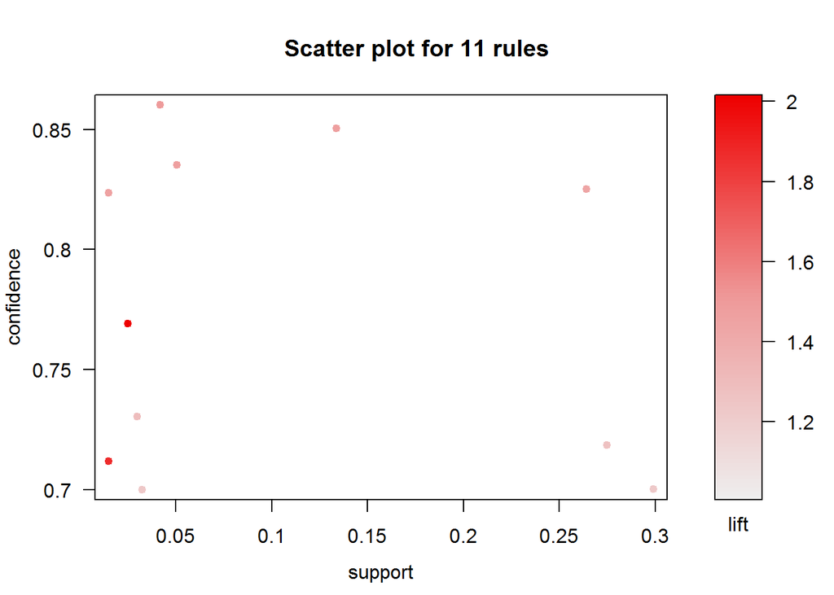

```r
library(arulesViz)
plot(rules.pruned)
```

图中的点颜色越深，表示lift值越大，可以看到lift值高的点集中在低support上。

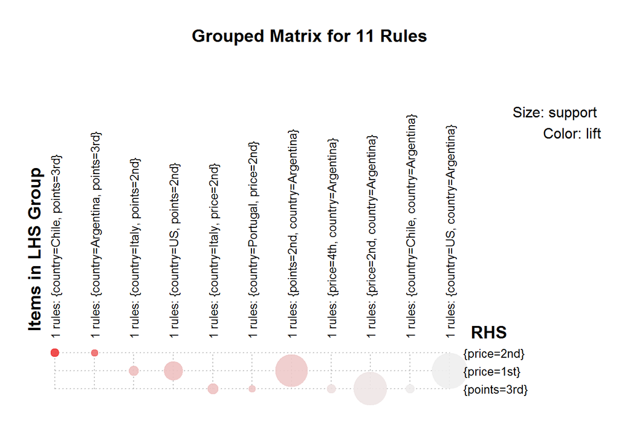

```r
plot(rules.pruned, method = "grouped")
```

提升度lift是圈的颜色深浅，圈的大小表示支持度support的大小。LHS的个数和分组中最重要（频繁）项集显示在列的标签里。lift从左上角到右下角逐渐减少。

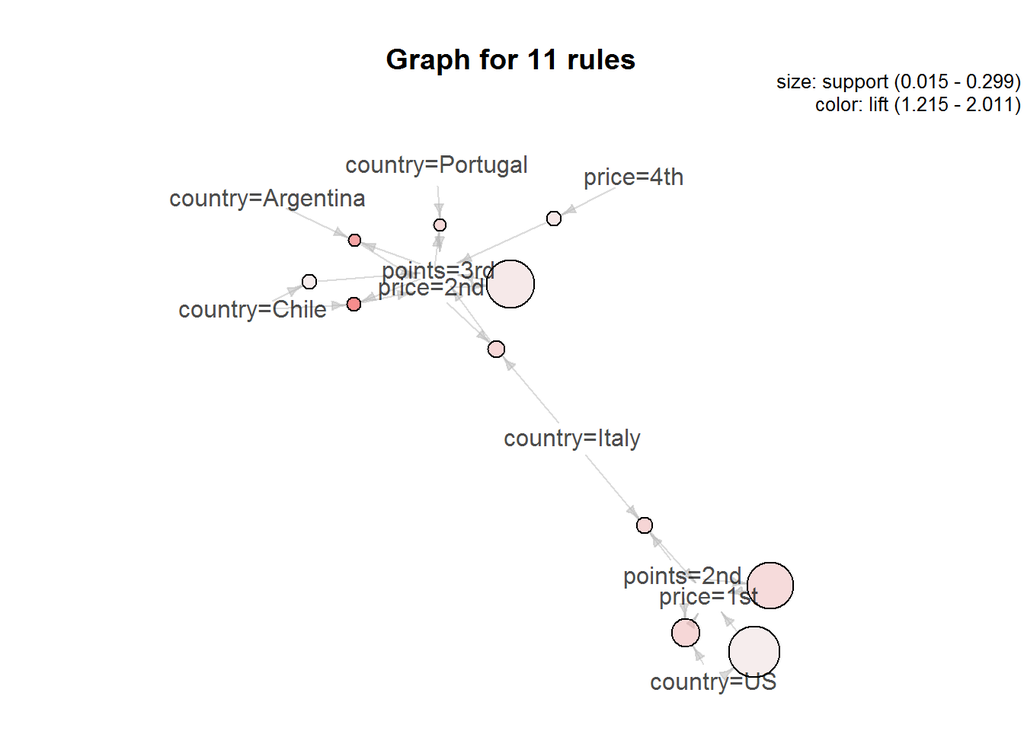

```r
plot(rules.pruned, method = "graph")
```

通过箭头和圆圈来表示关联规则，利用顶点代表项集，边表示规则中关系。圆圈越大表示支持度support越大，颜色越深表示提升度lift越大。